# Data analysis using pandas, matplotlib

# job data analysis

#### Data Analysis:The process of cleaning, analysing, interpreting, and displaying data using different approaches and business intelligence tools is known as data analysis. Data analysis tools assist you in uncovering key insights that lead to better informed and successful decision-making. It is concerned with the transformation of raw data into meaningful statistics, information, and explanations.

# Data processing

```python
import numpy as np
import pandas as pd
import matplotlib.pyplot as plt
```

#### reading a csv file using pandas

```python
data=pd.read_csv(r"C:\Users\giree\OneDrive\Desktop\projects ds\archive.zip")
data
```

|  | work_year | job_title | job_category | salary_currency | salary | salary_in_usd | employee_residence | experience_level | employment_type | work_setting | company_location | company_size |
| --- | --- | --- | --- | --- | --- | --- | --- | --- | --- | --- | --- | --- |
| 0 | 2023 | Data DevOps Engineer | Data Engineering | EUR | 88000 | 95012 | Germany | Mid-level | Full-time | Hybrid | Germany | L |
| 1 | 2023 | Data Architect | Data Architecture and Modeling | USD | 186000 | 186000 | United States | Senior | Full-time | In-person | United States | M |
| 2 | 2023 | Data Architect | Data Architecture and Modeling | USD | 81800 | 81800 | United States | Senior | Full-time | In-person | United States | M |
| 3 | 2023 | Data Scientist | Data Science and Research | USD | 212000 | 212000 | United States | Senior | Full-time | In-person | United States | M |
| 4 | 2023 | Data Scientist | Data Science and Research | USD | 93300 | 93300 | United States | Senior | Full-time | In-person | United States | M |
| ... | ... | ... | ... | ... | ... | ... | ... | ... | ... | ... | ... | ... |
| 9350 | 2021 | Data Specialist | Data Management and Strategy | USD | 165000 | 165000 | United States | Senior | Full-time | Remote | United States | L |
| 9351 | 2020 | Data Scientist | Data Science and Research | USD | 412000 | 412000 | United States | Senior | Full-time | Remote | United States | L |
| 9352 | 2021 | Principal Data Scientist | Data Science and Research | USD | 151000 | 151000 | United States | Mid-level | Full-time | Remote | United States | L |
| 9353 | 2020 | Data Scientist | Data Science and Research | USD | 105000 | 105000 | United States | Entry-level | Full-time | Remote | United States | S |
| 9354 | 2020 | Business Data Analyst | Data Analysis | USD | 100000 | 100000 | United States | Entry-level | Contract | Remote | United States | L |

9355 rows × 12 columns

#### info() gives detailed description about the details in the data frame

```python
data.info()
```

```
<class 'pandas.core.frame.DataFrame'>
RangeIndex: 9355 entries, 0 to 9354
Data columns (total 12 columns):
 #   Column              Non-Null Count  Dtype
---  ------              --------------  -----
 0   work_year           9355 non-null   int64
 1   job_title           9355 non-null   object
 2   job_category        9355 non-null   object
 3   salary_currency     9355 non-null   object
 4   salary              9355 non-null   int64
 5   salary_in_usd       9355 non-null   int64
 6   employee_residence  9355 non-null   object
 7   experience_level    9355 non-null   object
 8   employment_type     9355 non-null   object
 9   work_setting        9355 non-null   object
 10  company_location    9355 non-null   object
 11  company_size        9355 non-null   object
dtypes: int64(3), object(9)
memory usage: 877.2+ KB
```

#### checking for null values inside data

```python
data.isnull()
```

|  | work_year | job_title | job_category | salary_currency | salary | salary_in_usd | employee_residence | experience_level | employment_type | work_setting | company_location | company_size |
| --- | --- | --- | --- | --- | --- | --- | --- | --- | --- | --- | --- | --- |
| 0 | False | False | False | False | False | False | False | False | False | False | False | False |
| 1 | False | False | False | False | False | False | False | False | False | False | False | False |
| 2 | False | False | False | False | False | False | False | False | False | False | False | False |
| 3 | False | False | False | False | False | False | False | False | False | False | False | False |
| 4 | False | False | False | False | False | False | False | False | False | False | False | False |
| ... | ... | ... | ... | ... | ... | ... | ... | ... | ... | ... | ... | ... |
| 9350 | False | False | False | False | False | False | False | False | False | False | False | False |
| 9351 | False | False | False | False | False | False | False | False | False | False | False | False |
| 9352 | False | False | False | False | False | False | False | False | False | False | False | False |
| 9353 | False | False | False | False | False | False | False | False | False | False | False | False |
| 9354 | False | False | False | False | False | False | False | False | False | False | False | False |

9355 rows × 12 columns

```python
data.isnull().sum()
```

```
work_year             0
job_title             0
job_category          0
salary_currency       0
salary                0
salary_in_usd         0
employee_residence    0
experience_level      0
employment_type       0
work_setting          0
company_location      0
company_size          0
dtype: int64
```

#### applying aggregate methods to data frame

```python
sum_data=data['salary'].sum()
mean_data=data['salary'].mean()
print(sum_data)
print(mean_data)
```

```
1402576265
149927.98129342598
```

```python
data.notnull()
```

|  | work_year | job_title | job_category | salary_currency | salary | salary_in_usd | employee_residence | experience_level | employment_type | work_setting | company_location | company_size |
| --- | --- | --- | --- | --- | --- | --- | --- | --- | --- | --- | --- | --- |
| 0 | True | True | True | True | True | True | True | True | True | True | True | True |
| 1 | True | True | True | True | True | True | True | True | True | True | True | True |
| 2 | True | True | True | True | True | True | True | True | True | True | True | True |
| 3 | True | True | True | True | True | True | True | True | True | True | True | True |
| 4 | True | True | True | True | True | True | True | True | True | True | True | True |
| ... | ... | ... | ... | ... | ... | ... | ... | ... | ... | ... | ... | ... |
| 9350 | True | True | True | True | True | True | True | True | True | True | True | True |
| 9351 | True | True | True | True | True | True | True | True | True | True | True | True |
| 9352 | True | True | True | True | True | True | True | True | True | True | True | True |
| 9353 | True | True | True | True | True | True | True | True | True | True | True | True |
| 9354 | True | True | True | True | True | True | True | True | True | True | True | True |

9355 rows × 12 columns

```python
data.replace('experience_level','exp')
data
```

|  | work_year | job_title | job_category | salary_currency | salary | salary_in_usd | employee_residence | experience_level | employment_type | work_setting | company_location | company_size |
| --- | --- | --- | --- | --- | --- | --- | --- | --- | --- | --- | --- | --- |
| 0 | 2023 | Data DevOps Engineer | Data Engineering | EUR | 88000 | 95012 | Germany | Mid-level | Full-time | Hybrid | Germany | L |
| 1 | 2023 | Data Architect | Data Architecture and Modeling | USD | 186000 | 186000 | United States | Senior | Full-time | In-person | United States | M |
| 2 | 2023 | Data Architect | Data Architecture and Modeling | USD | 81800 | 81800 | United States | Senior | Full-time | In-person | United States | M |
| 3 | 2023 | Data Scientist | Data Science and Research | USD | 212000 | 212000 | United States | Senior | Full-time | In-person | United States | M |
| 4 | 2023 | Data Scientist | Data Science and Research | USD | 93300 | 93300 | United States | Senior | Full-time | In-person | United States | M |
| ... | ... | ... | ... | ... | ... | ... | ... | ... | ... | ... | ... | ... |
| 9350 | 2021 | Data Specialist | Data Management and Strategy | USD | 165000 | 165000 | United States | Senior | Full-time | Remote | United States | L |
| 9351 | 2020 | Data Scientist | Data Science and Research | USD | 412000 | 412000 | United States | Senior | Full-time | Remote | United States | L |
| 9352 | 2021 | Principal Data Scientist | Data Science and Research | USD | 151000 | 151000 | United States | Mid-level | Full-time | Remote | United States | L |
| 9353 | 2020 | Data Scientist | Data Science and Research | USD | 105000 | 105000 | United States | Entry-level | Full-time | Remote | United States | S |
| 9354 | 2020 | Business Data Analyst | Data Analysis | USD | 100000 | 100000 | United States | Entry-level | Contract | Remote | United States | L |

9355 rows × 12 columns

```python
data.salary.sum()
```

```
1402576265
```

```python
data.describe()
```

|  | work_year | salary | salary_in_usd |
| --- | --- | --- | --- |
| count | 9355.000000 | 9355.000000 | 9355.000000 |
| mean | 2022.760449 | 149927.981293 | 150299.495564 |
| std | 0.519470 | 63608.835387 | 63177.372024 |
| min | 2020.000000 | 14000.000000 | 15000.000000 |
| 25% | 2023.000000 | 105200.000000 | 105700.000000 |
| 50% | 2023.000000 | 143860.000000 | 143000.000000 |
| 75% | 2023.000000 | 187000.000000 | 186723.000000 |
| max | 2023.000000 | 450000.000000 | 450000.000000 |

# Data cleaning

#### Data cleaning is the process of fixing or removing incorrect, corrupted, incorrectly formatted, duplicate, or incomplete data within a dataset

```python
data.dropna(inplace=True)
data
```

|  | work_year | job_title | job_category | salary_currency | salary | salary_in_usd | employee_residence | experience_level | employment_type | work_setting | company_location | company_size |
| --- | --- | --- | --- | --- | --- | --- | --- | --- | --- | --- | --- | --- |
| 0 | 2023 | Data DevOps Engineer | Data Engineering | EUR | 88000 | 95012 | Germany | Mid-level | Full-time | Hybrid | Germany | L |
| 1 | 2023 | Data Architect | Data Architecture and Modeling | USD | 186000 | 186000 | United States | Senior | Full-time | In-person | United States | M |
| 2 | 2023 | Data Architect | Data Architecture and Modeling | USD | 81800 | 81800 | United States | Senior | Full-time | In-person | United States | M |
| 3 | 2023 | Data Scientist | Data Science and Research | USD | 212000 | 212000 | United States | Senior | Full-time | In-person | United States | M |
| 4 | 2023 | Data Scientist | Data Science and Research | USD | 93300 | 93300 | United States | Senior | Full-time | In-person | United States | M |
| ... | ... | ... | ... | ... | ... | ... | ... | ... | ... | ... | ... | ... |
| 9350 | 2021 | Data Specialist | Data Management and Strategy | USD | 165000 | 165000 | United States | Senior | Full-time | Remote | United States | L |
| 9351 | 2020 | Data Scientist | Data Science and Research | USD | 412000 | 412000 | United States | Senior | Full-time | Remote | United States | L |
| 9352 | 2021 | Principal Data Scientist | Data Science and Research | USD | 151000 | 151000 | United States | Mid-level | Full-time | Remote | United States | L |
| 9353 | 2020 | Data Scientist | Data Science and Research | USD | 105000 | 105000 | United States | Entry-level | Full-time | Remote | United States | S |
| 9354 | 2020 | Business Data Analyst | Data Analysis | USD | 100000 | 100000 | United States | Entry-level | Contract | Remote | United States | L |

9355 rows × 12 columns

#### filling missing values using pad/fillna methods

```python
data.fillna(method="ffill")
data
```

|  | work_year | job_title | job_category | salary_currency | salary | salary_in_usd | employee_residence | experience_level | employment_type | work_setting | company_location | company_size |
| --- | --- | --- | --- | --- | --- | --- | --- | --- | --- | --- | --- | --- |
| 0 | 2023 | Data DevOps Engineer | Data Engineering | EUR | 88000 | 95012 | Germany | Mid-level | Full-time | Hybrid | Germany | L |
| 1 | 2023 | Data Architect | Data Architecture and Modeling | USD | 186000 | 186000 | United States | Senior | Full-time | In-person | United States | M |
| 2 | 2023 | Data Architect | Data Architecture and Modeling | USD | 81800 | 81800 | United States | Senior | Full-time | In-person | United States | M |
| 3 | 2023 | Data Scientist | Data Science and Research | USD | 212000 | 212000 | United States | Senior | Full-time | In-person | United States | M |
| 4 | 2023 | Data Scientist | Data Science and Research | USD | 93300 | 93300 | United States | Senior | Full-time | In-person | United States | M |
| ... | ... | ... | ... | ... | ... | ... | ... | ... | ... | ... | ... | ... |
| 9350 | 2021 | Data Specialist | Data Management and Strategy | USD | 165000 | 165000 | United States | Senior | Full-time | Remote | United States | L |
| 9351 | 2020 | Data Scientist | Data Science and Research | USD | 412000 | 412000 | United States | Senior | Full-time | Remote | United States | L |
| 9352 | 2021 | Principal Data Scientist | Data Science and Research | USD | 151000 | 151000 | United States | Mid-level | Full-time | Remote | United States | L |
| 9353 | 2020 | Data Scientist | Data Science and Research | USD | 105000 | 105000 | United States | Entry-level | Full-time | Remote | United States | S |
| 9354 | 2020 | Business Data Analyst | Data Analysis | USD | 100000 | 100000 | United States | Entry-level | Contract | Remote | United States | L |

9355 rows × 12 columns

```python
data.experience_level = 'midlevel'
data
```

|  | work_year | job_title | job_category | salary_currency | salary | salary_in_usd | employee_residence | experience_level | employment_type | work_setting | company_location | company_size |
| --- | --- | --- | --- | --- | --- | --- | --- | --- | --- | --- | --- | --- |
| 0 | 2023 | Data DevOps Engineer | Data Engineering | EUR | 88000 | 95012 | Germany | midlevel | Full-time | Hybrid | Germany | L |
| 1 | 2023 | Data Architect | Data Architecture and Modeling | USD | 186000 | 186000 | United States | midlevel | Full-time | In-person | United States | M |
| 2 | 2023 | Data Architect | Data Architecture and Modeling | USD | 81800 | 81800 | United States | midlevel | Full-time | In-person | United States | M |
| 3 | 2023 | Data Scientist | Data Science and Research | USD | 212000 | 212000 | United States | midlevel | Full-time | In-person | United States | M |
| 4 | 2023 | Data Scientist | Data Science and Research | USD | 93300 | 93300 | United States | midlevel | Full-time | In-person | United States | M |
| ... | ... | ... | ... | ... | ... | ... | ... | ... | ... | ... | ... | ... |
| 9350 | 2021 | Data Specialist | Data Management and Strategy | USD | 165000 | 165000 | United States | midlevel | Full-time | Remote | United States | L |
| 9351 | 2020 | Data Scientist | Data Science and Research | USD | 412000 | 412000 | United States | midlevel | Full-time | Remote | United States | L |
| 9352 | 2021 | Principal Data Scientist | Data Science and Research | USD | 151000 | 151000 | United States | midlevel | Full-time | Remote | United States | L |
| 9353 | 2020 | Data Scientist | Data Science and Research | USD | 105000 | 105000 | United States | midlevel | Full-time | Remote | United States | S |
| 9354 | 2020 | Business Data Analyst | Data Analysis | USD | 100000 | 100000 | United States | midlevel | Contract | Remote | United States | L |

9355 rows × 12 columns

```python
data1=pd.get_dummies(data,columns=['work_year',"salary"])
data1
```

|  | job_title | job_category | salary_currency | salary_in_usd | employee_residence | experience_level | employment_type | work_setting | company_location | company_size | ... | salary_380000 | salary_383910 | salary_385000 | salary_392000 | salary_405000 | salary_409500 | salary_412000 | salary_416000 | salary_423000 | salary_450000 |
| --- | --- | --- | --- | --- | --- | --- | --- | --- | --- | --- | --- | --- | --- | --- | --- | --- | --- | --- | --- | --- | --- |
| 0 | Data DevOps Engineer | Data Engineering | EUR | 95012 | Germany | midlevel | Full-time | Hybrid | Germany | L | ... | False | False | False | False | False | False | False | False | False | False |
| 1 | Data Architect | Data Architecture and Modeling | USD | 186000 | United States | midlevel | Full-time | In-person | United States | M | ... | False | False | False | False | False | False | False | False | False | False |
| 2 | Data Architect | Data Architecture and Modeling | USD | 81800 | United States | midlevel | Full-time | In-person | United States | M | ... | False | False | False | False | False | False | False | False | False | False |
| 3 | Data Scientist | Data Science and Research | USD | 212000 | United States | midlevel | Full-time | In-person | United States | M | ... | False | False | False | False | False | False | False | False | False | False |
| 4 | Data Scientist | Data Science and Research | USD | 93300 | United States | midlevel | Full-time | In-person | United States | M | ... | False | False | False | False | False | False | False | False | False | False |
| ... | ... | ... | ... | ... | ... | ... | ... | ... | ... | ... | ... | ... | ... | ... | ... | ... | ... | ... | ... | ... | ... |
| 9350 | Data Specialist | Data Management and Strategy | USD | 165000 | United States | midlevel | Full-time | Remote | United States | L | ... | False | False | False | False | False | False | False | False | False | False |
| 9351 | Data Scientist | Data Science and Research | USD | 412000 | United States | midlevel | Full-time | Remote | United States | L | ... | False | False | False | False | False | False | True | False | False | False |
| 9352 | Principal Data Scientist | Data Science and Research | USD | 151000 | United States | midlevel | Full-time | Remote | United States | L | ... | False | False | False | False | False | False | False | False | False | False |
| 9353 | Data Scientist | Data Science and Research | USD | 105000 | United States | midlevel | Full-time | Remote | United States | S | ... | False | False | False | False | False | False | False | False | False | False |
| 9354 | Business Data Analyst | Data Analysis | USD | 100000 | United States | midlevel | Contract | Remote | United States | L | ... | False | False | False | False | False | False | False | False | False | False |

9355 rows × 1521 columns

```python
data1.head(10)
```

|  | job_title | job_category | salary_currency | salary_in_usd | employee_residence | experience_level | employment_type | work_setting | company_location | company_size | ... | salary_380000 | salary_383910 | salary_385000 | salary_392000 | salary_405000 | salary_409500 | salary_412000 | salary_416000 | salary_423000 | salary_450000 |
| --- | --- | --- | --- | --- | --- | --- | --- | --- | --- | --- | --- | --- | --- | --- | --- | --- | --- | --- | --- | --- | --- |
| 0 | Data DevOps Engineer | Data Engineering | EUR | 95012 | Germany | midlevel | Full-time | Hybrid | Germany | L | ... | False | False | False | False | False | False | False | False | False | False |
| 1 | Data Architect | Data Architecture and Modeling | USD | 186000 | United States | midlevel | Full-time | In-person | United States | M | ... | False | False | False | False | False | False | False | False | False | False |
| 2 | Data Architect | Data Architecture and Modeling | USD | 81800 | United States | midlevel | Full-time | In-person | United States | M | ... | False | False | False | False | False | False | False | False | False | False |
| 3 | Data Scientist | Data Science and Research | USD | 212000 | United States | midlevel | Full-time | In-person | United States | M | ... | False | False | False | False | False | False | False | False | False | False |
| 4 | Data Scientist | Data Science and Research | USD | 93300 | United States | midlevel | Full-time | In-person | United States | M | ... | False | False | False | False | False | False | False | False | False | False |
| 5 | Data Scientist | Data Science and Research | USD | 130000 | United States | midlevel | Full-time | Remote | United States | M | ... | False | False | False | False | False | False | False | False | False | False |
| 6 | Data Scientist | Data Science and Research | USD | 100000 | United States | midlevel | Full-time | Remote | United States | M | ... | False | False | False | False | False | False | False | False | False | False |
| 7 | Machine Learning Researcher | Machine Learning and AI | USD | 224400 | United States | midlevel | Full-time | In-person | United States | M | ... | False | False | False | False | False | False | False | False | False | False |
| 8 | Machine Learning Researcher | Machine Learning and AI | USD | 138700 | United States | midlevel | Full-time | In-person | United States | M | ... | False | False | False | False | False | False | False | False | False | False |
| 9 | Data Engineer | Data Engineering | USD | 210000 | United States | midlevel | Full-time | Remote | United States | M | ... | False | False | False | False | False | False | False | False | False | False |

10 rows × 1521 columns

```python
dummies=pd.get_dummies(data,columns=["salary_currency","salary_in_usd"])
dummies.head(10)
```

|  | work_year | job_title | job_category | salary | employee_residence | experience_level | employment_type | work_setting | company_location | company_size | ... | salary_in_usd_385000 | salary_in_usd_392000 | salary_in_usd_399880 | salary_in_usd_405000 | salary_in_usd_412000 | salary_in_usd_416000 | salary_in_usd_423000 | salary_in_usd_430640 | salary_in_usd_430967 | salary_in_usd_450000 |
| --- | --- | --- | --- | --- | --- | --- | --- | --- | --- | --- | --- | --- | --- | --- | --- | --- | --- | --- | --- | --- | --- |
| 0 | 2023 | Data DevOps Engineer | Data Engineering | 88000 | Germany | midlevel | Full-time | Hybrid | Germany | L | ... | False | False | False | False | False | False | False | False | False | False |
| 1 | 2023 | Data Architect | Data Architecture and Modeling | 186000 | United States | midlevel | Full-time | In-person | United States | M | ... | False | False | False | False | False | False | False | False | False | False |
| 2 | 2023 | Data Architect | Data Architecture and Modeling | 81800 | United States | midlevel | Full-time | In-person | United States | M | ... | False | False | False | False | False | False | False | False | False | False |
| 3 | 2023 | Data Scientist | Data Science and Research | 212000 | United States | midlevel | Full-time | In-person | United States | M | ... | False | False | False | False | False | False | False | False | False | False |
| 4 | 2023 | Data Scientist | Data Science and Research | 93300 | United States | midlevel | Full-time | In-person | United States | M | ... | False | False | False | False | False | False | False | False | False | False |
| 5 | 2023 | Data Scientist | Data Science and Research | 130000 | United States | midlevel | Full-time | Remote | United States | M | ... | False | False | False | False | False | False | False | False | False | False |
| 6 | 2023 | Data Scientist | Data Science and Research | 100000 | United States | midlevel | Full-time | Remote | United States | M | ... | False | False | False | False | False | False | False | False | False | False |
| 7 | 2023 | Machine Learning Researcher | Machine Learning and AI | 224400 | United States | midlevel | Full-time | In-person | United States | M | ... | False | False | False | False | False | False | False | False | False | False |
| 8 | 2023 | Machine Learning Researcher | Machine Learning and AI | 138700 | United States | midlevel | Full-time | In-person | United States | M | ... | False | False | False | False | False | False | False | False | False | False |
| 9 | 2023 | Data Engineer | Data Engineering | 210000 | United States | midlevel | Full-time | Remote | United States | M | ... | False | False | False | False | False | False | False | False | False | False |

10 rows × 1807 columns

### dropping column using drop()

```python
data.drop("salary",axis=1,inplace=True)
data
```

|  | work_year | job_title | job_category | salary_currency | salary_in_usd | employee_residence | experience_level | employment_type | work_setting | company_location | company_size |
| --- | --- | --- | --- | --- | --- | --- | --- | --- | --- | --- | --- |
| 0 | 2023 | Data DevOps Engineer | Data Engineering | EUR | 95012 | Germany | midlevel | Full-time | Hybrid | Germany | L |
| 1 | 2023 | Data Architect | Data Architecture and Modeling | USD | 186000 | United States | midlevel | Full-time | In-person | United States | M |
| 2 | 2023 | Data Architect | Data Architecture and Modeling | USD | 81800 | United States | midlevel | Full-time | In-person | United States | M |
| 3 | 2023 | Data Scientist | Data Science and Research | USD | 212000 | United States | midlevel | Full-time | In-person | United States | M |
| 4 | 2023 | Data Scientist | Data Science and Research | USD | 93300 | United States | midlevel | Full-time | In-person | United States | M |
| ... | ... | ... | ... | ... | ... | ... | ... | ... | ... | ... | ... |
| 9350 | 2021 | Data Specialist | Data Management and Strategy | USD | 165000 | United States | midlevel | Full-time | Remote | United States | L |
| 9351 | 2020 | Data Scientist | Data Science and Research | USD | 412000 | United States | midlevel | Full-time | Remote | United States | L |
| 9352 | 2021 | Principal Data Scientist | Data Science and Research | USD | 151000 | United States | midlevel | Full-time | Remote | United States | L |
| 9353 | 2020 | Data Scientist | Data Science and Research | USD | 105000 | United States | midlevel | Full-time | Remote | United States | S |
| 9354 | 2020 | Business Data Analyst | Data Analysis | USD | 100000 | United States | midlevel | Contract | Remote | United States | L |

9355 rows × 11 columns

```python
data.dropna(axis=1)
data.isna().sum()
```

```
work_year             0
job_title             0
job_category          0
salary_currency       0
salary_in_usd         0
employee_residence    0
experience_level      0
employment_type       0
work_setting          0
company_location      0
company_size          0
dtype: int64
```

```python
data.corr
```

```
<bound method DataFrame.corr of       work_year                 job_title                    job_category  \
0          2023      Data DevOps Engineer                Data Engineering
1          2023            Data Architect  Data Architecture and Modeling
2          2023            Data Architect  Data Architecture and Modeling
3          2023            Data Scientist       Data Science and Research
4          2023            Data Scientist       Data Science and Research
...         ...                       ...                             ...
9350       2021           Data Specialist    Data Management and Strategy
9351       2020            Data Scientist       Data Science and Research
9352       2021  Principal Data Scientist       Data Science and Research
9353       2020            Data Scientist       Data Science and Research
9354       2020     Business Data Analyst                   Data Analysis

     salary_currency  salary_in_usd employee_residence experience_level  \
0                EUR          95012            Germany         midlevel
```

[output cut: 25 more lines]

```python
data.cov
```

```
<bound method DataFrame.cov of       work_year                 job_title                    job_category  \
0          2023      Data DevOps Engineer                Data Engineering
1          2023            Data Architect  Data Architecture and Modeling
2          2023            Data Architect  Data Architecture and Modeling
3          2023            Data Scientist       Data Science and Research
4          2023            Data Scientist       Data Science and Research
...         ...                       ...                             ...
9350       2021           Data Specialist    Data Management and Strategy
9351       2020            Data Scientist       Data Science and Research
9352       2021  Principal Data Scientist       Data Science and Research
9353       2020            Data Scientist       Data Science and Research
9354       2020     Business Data Analyst                   Data Analysis

     salary_currency  salary_in_usd employee_residence experience_level  \
0                EUR          95012            Germany         midlevel
```

[output cut: 25 more lines]

### checking all available columns by looping through columns

```python
for i in data.columns:
    print(i)
```

```
work_year
job_title
job_category
salary_currency
salary_in_usd
employee_residence
experience_level
employment_type
work_setting
company_location
company_size
```

```python
mean=data.salary_in_usd.mean()
mean
```

```
150299.4955638696
```

```python
data.company_location="United States"
print(data)
data1=len(data)
data1
```

```
      work_year                 job_title                    job_category  \
0          2023      Data DevOps Engineer                Data Engineering
1          2023            Data Architect  Data Architecture and Modeling
2          2023            Data Architect  Data Architecture and Modeling
3          2023            Data Scientist       Data Science and Research
4          2023            Data Scientist       Data Science and Research
...         ...                       ...                             ...
9350       2021           Data Specialist    Data Management and Strategy
9351       2020            Data Scientist       Data Science and Research
9352       2021  Principal Data Scientist       Data Science and Research
9353       2020            Data Scientist       Data Science and Research
9354       2020     Business Data Analyst                   Data Analysis

     salary_currency  salary_in_usd employee_residence experience_level  \
0                EUR          95012            Germany         midlevel
```

[output cut: 25 more lines]

```
9355
```

### applying different arithmetic operations on columns

```python
data_salary=data.salary_in_usd-mean
data_salary
```

```
0       -55287.495564
1        35700.504436
2       -68499.495564
3        61700.504436
4       -56999.495564
            ...
9350     14700.504436
9351    261700.504436
9352       700.504436
9353    -45299.495564
9354    -50299.495564
Name: salary_in_usd, Length: 9355, dtype: float64
```

```python
data.drop(columns=["work_setting"])
```

|  | work_year | job_title | job_category | salary_currency | salary_in_usd | employee_residence | experience_level | employment_type | company_location | company_size |
| --- | --- | --- | --- | --- | --- | --- | --- | --- | --- | --- |
| 0 | 2023 | Data DevOps Engineer | Data Engineering | EUR | 95012 | Germany | midlevel | Full-time | United States | L |
| 1 | 2023 | Data Architect | Data Architecture and Modeling | USD | 186000 | United States | midlevel | Full-time | United States | M |
| 2 | 2023 | Data Architect | Data Architecture and Modeling | USD | 81800 | United States | midlevel | Full-time | United States | M |
| 3 | 2023 | Data Scientist | Data Science and Research | USD | 212000 | United States | midlevel | Full-time | United States | M |
| 4 | 2023 | Data Scientist | Data Science and Research | USD | 93300 | United States | midlevel | Full-time | United States | M |
| ... | ... | ... | ... | ... | ... | ... | ... | ... | ... | ... |
| 9350 | 2021 | Data Specialist | Data Management and Strategy | USD | 165000 | United States | midlevel | Full-time | United States | L |
| 9351 | 2020 | Data Scientist | Data Science and Research | USD | 412000 | United States | midlevel | Full-time | United States | L |
| 9352 | 2021 | Principal Data Scientist | Data Science and Research | USD | 151000 | United States | midlevel | Full-time | United States | L |
| 9353 | 2020 | Data Scientist | Data Science and Research | USD | 105000 | United States | midlevel | Full-time | United States | S |
| 9354 | 2020 | Business Data Analyst | Data Analysis | USD | 100000 | United States | midlevel | Contract | United States | L |

9355 rows × 10 columns

```python
length=data.columns
print(length)
print(len(length))
```

```
Index(['work_year', 'job_title', 'job_category', 'salary_currency',
       'salary_in_usd', 'employee_residence', 'experience_level',
       'employment_type', 'work_setting', 'company_location', 'company_size'],
      dtype='object')
11
```

### We can also perform slicing on data frame

### retrieving rows from data frame using slicing from 1000 to 1009 indexes

```python
data[1000:1010]
```

|  | work_year | job_title | job_category | salary_currency | salary_in_usd | employee_residence | experience_level | employment_type | work_setting | company_location | company_size |
| --- | --- | --- | --- | --- | --- | --- | --- | --- | --- | --- | --- |
| 1000 | 2023 | Business Intelligence Analyst | BI and Visualization | USD | 97000 | United States | midlevel | Full-time | In-person | United States | M |
| 1001 | 2023 | Data Analyst | Data Analysis | USD | 175000 | United States | midlevel | Full-time | Remote | United States | M |
| 1002 | 2023 | Data Analyst | Data Analysis | USD | 150000 | United States | midlevel | Full-time | Remote | United States | M |
| 1003 | 2023 | Data Product Manager | Leadership and Management | USD | 145000 | United States | midlevel | Full-time | In-person | United States | M |
| 1004 | 2023 | Data Product Manager | Leadership and Management | USD | 120000 | United States | midlevel | Full-time | In-person | United States | M |
| 1005 | 2023 | Data Engineer | Data Engineering | USD | 88000 | United States | midlevel | Full-time | In-person | United States | M |
| 1006 | 2023 | Data Engineer | Data Engineering | USD | 60000 | United States | midlevel | Full-time | In-person | United States | M |
| 1007 | 2023 | Data Management Specialist | Data Management and Strategy | USD | 123000 | United States | midlevel | Full-time | In-person | United States | M |
| 1008 | 2023 | Data Management Specialist | Data Management and Strategy | USD | 93593 | United States | midlevel | Full-time | In-person | United States | M |
| 1009 | 2023 | ML Engineer | Machine Learning and AI | USD | 276000 | United States | midlevel | Full-time | In-person | United States | M |

### sorting the indexes using sort_index()

```python
data.sort_index(ascending=False)
```

|  | work_year | job_title | job_category | salary_currency | salary_in_usd | employee_residence | experience_level | employment_type | work_setting | company_location | company_size |
| --- | --- | --- | --- | --- | --- | --- | --- | --- | --- | --- | --- |
| 9354 | 2020 | Business Data Analyst | Data Analysis | USD | 100000 | United States | midlevel | Contract | Remote | United States | L |
| 9353 | 2020 | Data Scientist | Data Science and Research | USD | 105000 | United States | midlevel | Full-time | Remote | United States | S |
| 9352 | 2021 | Principal Data Scientist | Data Science and Research | USD | 151000 | United States | midlevel | Full-time | Remote | United States | L |
| 9351 | 2020 | Data Scientist | Data Science and Research | USD | 412000 | United States | midlevel | Full-time | Remote | United States | L |
| 9350 | 2021 | Data Specialist | Data Management and Strategy | USD | 165000 | United States | midlevel | Full-time | Remote | United States | L |
| ... | ... | ... | ... | ... | ... | ... | ... | ... | ... | ... | ... |
| 4 | 2023 | Data Scientist | Data Science and Research | USD | 93300 | United States | midlevel | Full-time | In-person | United States | M |
| 3 | 2023 | Data Scientist | Data Science and Research | USD | 212000 | United States | midlevel | Full-time | In-person | United States | M |
| 2 | 2023 | Data Architect | Data Architecture and Modeling | USD | 81800 | United States | midlevel | Full-time | In-person | United States | M |
| 1 | 2023 | Data Architect | Data Architecture and Modeling | USD | 186000 | United States | midlevel | Full-time | In-person | United States | M |
| 0 | 2023 | Data DevOps Engineer | Data Engineering | EUR | 95012 | Germany | midlevel | Full-time | Hybrid | United States | L |

9355 rows × 11 columns

#### sorting values using column

```python
data.sort_values(by="work_year",ascending=True)
```

|  | work_year | job_title | job_category | salary_currency | salary_in_usd | employee_residence | experience_level | employment_type | work_setting | company_location | company_size |
| --- | --- | --- | --- | --- | --- | --- | --- | --- | --- | --- | --- |
| 9354 | 2020 | Business Data Analyst | Data Analysis | USD | 100000 | United States | midlevel | Contract | Remote | United States | L |
| 9180 | 2020 | Machine Learning Engineer | Machine Learning and AI | USD | 138000 | United States | midlevel | Full-time | Remote | United States | S |
| 9219 | 2020 | Data Engineer | Data Engineering | EUR | 70139 | France | midlevel | Full-time | Hybrid | United States | L |
| 9157 | 2020 | Research Scientist | Data Science and Research | USD | 450000 | United States | midlevel | Full-time | In-person | United States | M |
| 9304 | 2020 | Director of Data Science | Data Science and Research | USD | 325000 | United States | midlevel | Full-time | Remote | United States | L |
| ... | ... | ... | ... | ... | ... | ... | ... | ... | ... | ... | ... |
| 3120 | 2023 | Data Analyst | Data Analysis | USD | 192000 | United States | midlevel | Full-time | Remote | United States | M |
| 3121 | 2023 | Data Analyst | Data Analysis | USD | 138240 | United States | midlevel | Full-time | Remote | United States | M |
| 3122 | 2023 | Machine Learning Engineer | Machine Learning and AI | USD | 225000 | United States | midlevel | Full-time | In-person | United States | M |
| 3142 | 2023 | Data Scientist | Data Science and Research | EUR | 25912 | Italy | midlevel | Full-time | Remote | United States | S |
| 4677 | 2023 | Analytics Engineer | Leadership and Management | USD | 221300 | United States | midlevel | Full-time | In-person | United States | M |

9355 rows × 11 columns

### Applying rank method() to the dataframe

```python
data.rank(axis=0,method="average")
```

|  | work_year | job_title | job_category | salary_currency | salary_in_usd | employee_residence | experience_level | employment_type | work_setting | company_location | company_size |
| --- | --- | --- | --- | --- | --- | --- | --- | --- | --- | --- | --- |
| 0 | 5629.0 | 2697.5 | 3164.5 | 231.5 | 1867.0 | 428.5 | 4678.0 | 4685.5 | 96.0 | 4678.0 | 374.5 |
| 1 | 5629.0 | 2590.0 | 1905.0 | 5060.0 | 7002.5 | 5307.5 | 4678.0 | 4685.5 | 3056.5 | 4678.0 | 4972.5 |
| 2 | 5629.0 | 2590.0 | 1905.0 | 5060.0 | 1322.0 | 5307.5 | 4678.0 | 4685.5 | 3056.5 | 4678.0 | 4972.5 |
| 3 | 5629.0 | 6341.0 | 5917.5 | 5060.0 | 7925.5 | 5307.5 | 4678.0 | 4685.5 | 3056.5 | 4678.0 | 4972.5 |
| 4 | 5629.0 | 6341.0 | 5917.5 | 5060.0 | 1733.5 | 5307.5 | 4678.0 | 4685.5 | 3056.5 | 4678.0 | 4972.5 |
| ... | ... | ... | ... | ... | ... | ... | ... | ... | ... | ... | ... |
| 9350 | 170.0 | 7357.5 | 4325.0 | 5060.0 | 5909.0 | 5307.5 | 4678.0 | 4685.5 | 7638.5 | 4678.0 | 374.5 |
| 9351 | 36.0 | 6341.0 | 5917.5 | 5060.0 | 9350.0 | 5307.5 | 4678.0 | 4685.5 | 7638.5 | 4678.0 | 374.5 |
| 9352 | 170.0 | 8880.5 | 5917.5 | 5060.0 | 5218.5 | 5307.5 | 4678.0 | 4685.5 | 7638.5 | 4678.0 | 374.5 |
| 9353 | 36.0 | 6341.0 | 5917.5 | 5060.0 | 2276.0 | 5307.5 | 4678.0 | 4685.5 | 7638.5 | 4678.0 | 9276.0 |
| 9354 | 36.0 | 770.5 | 1047.0 | 5060.0 | 2028.0 | 5307.5 | 4678.0 | 10.0 | 7638.5 | 4678.0 | 374.5 |

9355 rows × 11 columns

```python
data.cumsum()
data
```

|  | work_year | job_title | job_category | salary_currency | salary_in_usd | employee_residence | experience_level | employment_type | work_setting | company_location | company_size |
| --- | --- | --- | --- | --- | --- | --- | --- | --- | --- | --- | --- |
| 0 | 2023 | Data DevOps Engineer | Data Engineering | EUR | 95012 | Germany | midlevel | Full-time | Hybrid | United States | L |
| 1 | 2023 | Data Architect | Data Architecture and Modeling | USD | 186000 | United States | midlevel | Full-time | In-person | United States | M |
| 2 | 2023 | Data Architect | Data Architecture and Modeling | USD | 81800 | United States | midlevel | Full-time | In-person | United States | M |
| 3 | 2023 | Data Scientist | Data Science and Research | USD | 212000 | United States | midlevel | Full-time | In-person | United States | M |
| 4 | 2023 | Data Scientist | Data Science and Research | USD | 93300 | United States | midlevel | Full-time | In-person | United States | M |
| ... | ... | ... | ... | ... | ... | ... | ... | ... | ... | ... | ... |
| 9350 | 2021 | Data Specialist | Data Management and Strategy | USD | 165000 | United States | midlevel | Full-time | Remote | United States | L |
| 9351 | 2020 | Data Scientist | Data Science and Research | USD | 412000 | United States | midlevel | Full-time | Remote | United States | L |
| 9352 | 2021 | Principal Data Scientist | Data Science and Research | USD | 151000 | United States | midlevel | Full-time | Remote | United States | L |
| 9353 | 2020 | Data Scientist | Data Science and Research | USD | 105000 | United States | midlevel | Full-time | Remote | United States | S |
| 9354 | 2020 | Business Data Analyst | Data Analysis | USD | 100000 | United States | midlevel | Contract | Remote | United States | L |

9355 rows × 11 columns

```python
data['avg_salary']=data.salary_in_usd/12
data
```

|  | work_year | job_title | job_category | salary_currency | salary_in_usd | employee_residence | experience_level | employment_type | work_setting | company_location | company_size | avg_salary |
| --- | --- | --- | --- | --- | --- | --- | --- | --- | --- | --- | --- | --- |
| 0 | 2023 | Data DevOps Engineer | Data Engineering | EUR | 95012 | Germany | midlevel | Full-time | Hybrid | United States | L | 7917.666667 |
| 1 | 2023 | Data Architect | Data Architecture and Modeling | USD | 186000 | United States | midlevel | Full-time | In-person | United States | M | 15500.000000 |
| 2 | 2023 | Data Architect | Data Architecture and Modeling | USD | 81800 | United States | midlevel | Full-time | In-person | United States | M | 6816.666667 |
| 3 | 2023 | Data Scientist | Data Science and Research | USD | 212000 | United States | midlevel | Full-time | In-person | United States | M | 17666.666667 |
| 4 | 2023 | Data Scientist | Data Science and Research | USD | 93300 | United States | midlevel | Full-time | In-person | United States | M | 7775.000000 |
| ... | ... | ... | ... | ... | ... | ... | ... | ... | ... | ... | ... | ... |
| 9350 | 2021 | Data Specialist | Data Management and Strategy | USD | 165000 | United States | midlevel | Full-time | Remote | United States | L | 13750.000000 |
| 9351 | 2020 | Data Scientist | Data Science and Research | USD | 412000 | United States | midlevel | Full-time | Remote | United States | L | 34333.333333 |
| 9352 | 2021 | Principal Data Scientist | Data Science and Research | USD | 151000 | United States | midlevel | Full-time | Remote | United States | L | 12583.333333 |
| 9353 | 2020 | Data Scientist | Data Science and Research | USD | 105000 | United States | midlevel | Full-time | Remote | United States | S | 8750.000000 |
| 9354 | 2020 | Business Data Analyst | Data Analysis | USD | 100000 | United States | midlevel | Contract | Remote | United States | L | 8333.333333 |

9355 rows × 12 columns

# Introduction

#### Data visualization is the graphic representation of data. It involves producing images that communicate relationships among the represented data to viewers. Visualizing data is an essential part of data analysis and machine learning. We'll use Python libraries Matplotlib and Seaborn to learn and apply some popular data visualization techniques.

```python
import matplotlib.pyplot as plt
import seaborn as sns
```

### reteiving columns from dataframe. figsize() helps to adjust the size of the figure adding labels to both axis using plt.xlabel() and plt.ylabel() and title using title(). grid() helps to make the figure more efficient

### Scatter plots are the graphs that present the relationship between two variables in a data-se

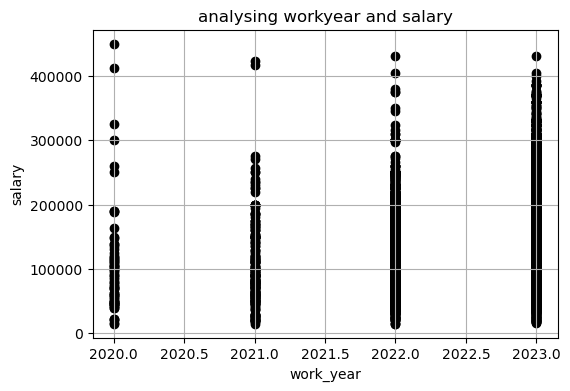

```python
work_year=data['work_year']
salary=data['salary_in_usd']
plt.figure(figsize=(6,4))
plt.scatter(work_year,salary,color='black')
plt.xlabel("work_year")
plt.ylabel("salary")
plt.grid(True)
plt.title("analysing workyear and salary");
```

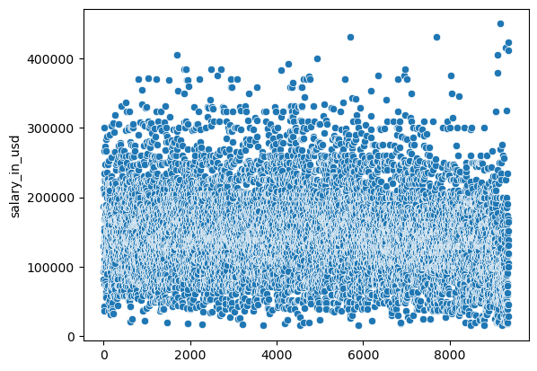

```python
 sns.scatterplot(data.salary_in_usd);
```

### A histogram is a graph showing frequency distributions. It is a graph showing the number of observations within each given interval.

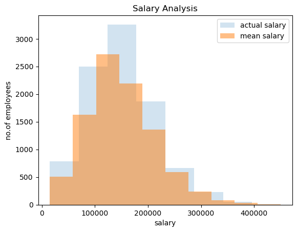

```python
salary_mean=data['salary_in_usd']
plt.title("Salary Analysis")
plt.xlabel("salary")
plt.ylabel("no.of employees")
plt.legend("salary")
plt.hist(data.salary_in_usd,bins=8,alpha=0.2)
plt.hist(salary_mean,bins=10,alpha=0.5)
plt.legend(["actual salary","mean salary"])#alpha used to reduce opesity i,e colour
```

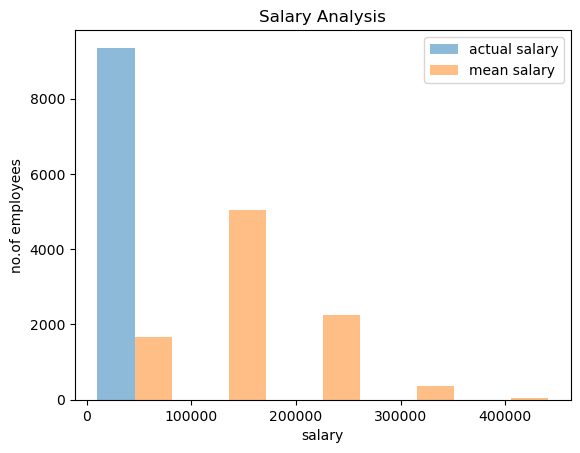

```python
salary_mean=data['salary_in_usd']
plt.title("Salary Analysis")
plt.xlabel("salary")
plt.ylabel("no.of employees")
plt.legend("salary")
plt.hist([data.avg_salary,data.salary_in_usd],bins=5,alpha=0.5)
plt.legend(["actual salary","mean salary"]);
#alpha used to reduce opesity i,e colour
```

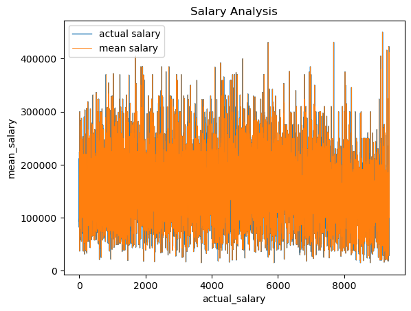

```python
salary_mean=data['salary_in_usd']
plt.title("Salary Analysis")
plt.xlabel("actual_salary")
plt.ylabel("mean_salary")
plt.legend("salary")
plt.plot(data.salary_in_usd,ls="-",lw=1)
plt.plot(salary_mean,lw=0.5)
plt.legend(["actual salary","mean salary"]);
```

### grouping the data by column name using groupby()

```python
emp_salary_mean=data.groupby("employee_residence")[["salary_in_usd"]].mean()
emp_salary_mean
```

| employee_residence | salary_in_usd |
| --- | --- |
| Algeria | 100000.000000 |
| American Samoa | 45555.000000 |
| Andorra | 50745.000000 |
| Argentina | 56444.444444 |
| Armenia | 33500.000000 |
| ... | ... |
| United Arab Emirates | 100000.000000 |
| United Kingdom | 104920.303167 |
| United States | 158586.128741 |
| Uzbekistan | 82000.000000 |
| Vietnam | 44200.000000 |

83 rows × 1 columns

### plotting using emp_salary_mean column

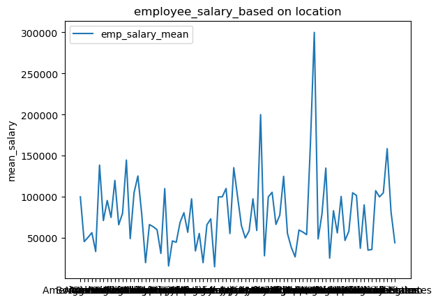

```python
plt.plot(emp_salary_mean)
plt.title("employee_salary_based on location")
plt.ylabel("mean_salary")
plt.legend(["emp_salary_mean"])
plt.show();
```

### loading datasets using load_dataset() from sns module

```python
#  heatmap used to visualize 2d data or a matrix
df=sns.load_dataset("flights")
print(df)
# Load data into a Pandas dataframe
flowers_df = sns.load_dataset("iris")
print(flowers_df)
```

```
     year month  passengers
0    1949   Jan         112
1    1949   Feb         118
2    1949   Mar         132
3    1949   Apr         129
4    1949   May         121
..    ...   ...         ...
139  1960   Aug         606
140  1960   Sep         508
141  1960   Oct         461
142  1960   Nov         390
143  1960   Dec         432

[144 rows x 3 columns]
     sepal_length  sepal_width  petal_length  petal_width    species
0             5.1          3.5           1.4          0.2     setosa
1             4.9          3.0           1.4          0.2     setosa
2             4.7          3.2           1.3          0.2     setosa
3             4.6          3.1           1.5          0.2     setosa
4             5.0          3.6           1.4          0.2     setosa
..            ...          ...           ...          ...        ...
145           6.7          3.0           5.2          2.3  virginica
146           6.3          2.5           5.0          1.9  virginica
147           6.5          3.0           5.2          2.0  virginica
148           6.2          3.4           5.4          2.3  virginica
149           5.9          3.0           5.1          1.8  virginica

[150 rows x 5 columns]
```

### ploting a graph using passengers column from dataframe

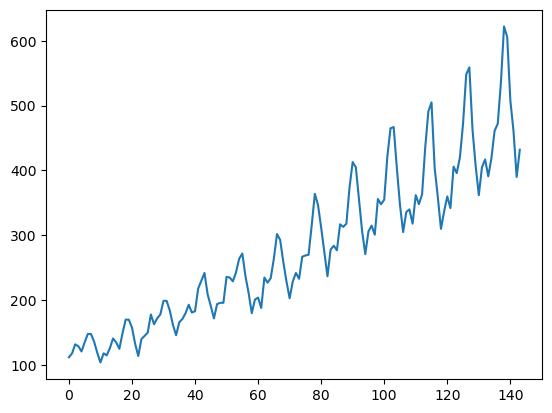

```python
plt.plot(df.passengers);
```

### Heat map is a two-dimensional graphical representation of data, each value in a matrix is represented by a different colour

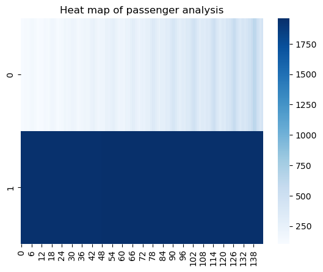

```python
df1=flights_df.passengers
df2=flights_df.year
sns.heatmap(data=[df1,df2],fmt="d",cmap="Blues")
plt.title("Heat map of passenger analysis")
```

## subplot

#### The subplot() function takes three arguments that describes the layout of the figure.the layout is organized in rows and columns, which are represented by the first and second argument.The third argument represents the index of the current plot.

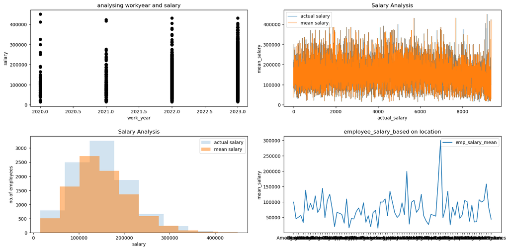

```python
fig, axes = plt.subplots(2, 2, figsize=(16, 8))

# Pass the axes into seaborn
axes[0,0].set_title("analysing workyear and salary")
work_year=data['work_year']
salary=data['salary_in_usd']
axes[0,0].scatter(work_year,salary,color='black')
axes[0,0].set_xlabel("work_year")
axes[0,0].set_ylabel("salary")



# Use the axes for plotting
axes[0,1].set_title("Salary Analysis")
salary_mean=data['salary_in_usd']
axes[0,1].set_xlabel("actual_salary")
axes[0,1].set_ylabel("mean_salary")
axes[0,1].legend("salary")
axes[0,1].plot(data.salary_in_usd,ls="-",lw=1)
axes[0,1].plot(salary_mean,lw=0.5)
axes[0,1].legend(["actual salary","mean salary"]);


# Pass the axes into seaborn
axes[1,0].set_title("Salary Analysis")
salary_mean=data['salary_in_usd']
axes[1,0].set_xlabel("salary")
axes[1,0].set_ylabel("no.of employees")
axes[1,0].legend("salary")
axes[1,0].hist(data.salary_in_usd,bins=8,alpha=0.2)
axes[1,0].hist(salary_mean,bins=10,alpha=0.5)
axes[1,0].legend(["actual salary","mean salary"])

# Pass the axes into seaborn
axes[1,1].set_title("employee_salary_based on location")
axes[1,1].plot(emp_salary_mean)
axes[1,1].set_ylabel("mean_salary")
axes[1,1].legend(["emp_salary_mean"])


plt.tight_layout(pad=2);
```